# Time Series Homework: Chapter 4 Lesson 1

Tristan Farrow

## Questions

### Question 1 - Gaussian White Noise (30 points)

#### a) Simulate a realization of Gaussian White Noise and plot it. Use 50 points and $\sigma^2=2$

**NoteAnswer**

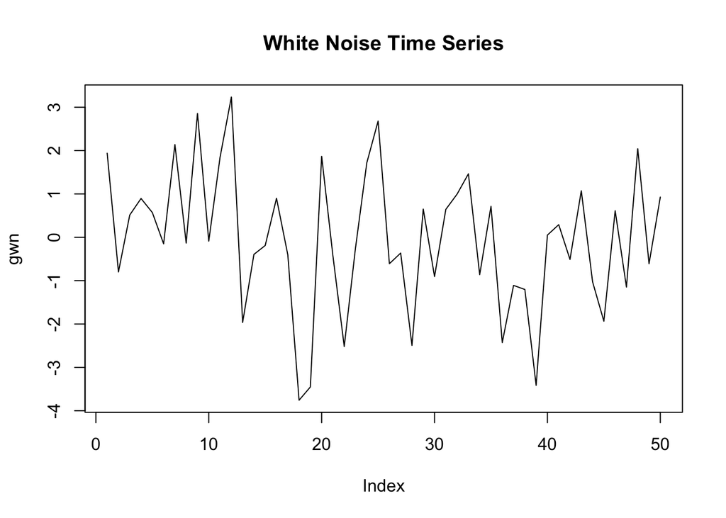

```r
n <- 50           # number of points
sigma2 <- 2       # variance
sigma <- sqrt(sigma2)  # standard deviation

# Set seed for reproducibility (optional)
set.seed(42)

# Simulate Gaussian White Noise
gwn <- rnorm(n, mean = 0, sd = sigma)

# Time Series Plot
plot(gwn, type = "l", main = "White Noise Time Series")
```

#### b) Estimate the second order properties of the sample. Why don’t they match exactly with the parameters values you used to create it?

**NoteAnswer**

```r
cat("Mean:", mean(gwn), "\n")
```

```
Mean: -0.05044752
```

```r
acf(gwn, type = "covariance",plot = FALSE)
```

```
Autocovariances of series 'gwn', by lag

      0       1       2       3       4       5       6       7       8       9
 2.5988  0.1523  0.0793  0.0306  0.1761  0.2475 -0.3260 -0.6323  0.5698  0.2110
     10      11      12      13      14      15      16
-0.3204 -0.0470 -0.4845  0.0203 -0.4959 -0.0203  0.0223
```

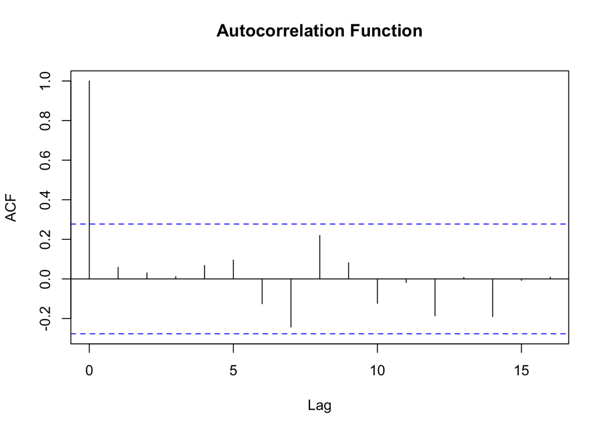

```r
acf(gwn, main = "Autocorrelation Function")
```

#### c) Use the classical decomposition on your simulated series, plot the results.

**NoteAnswer**

```r
data_ts <- tsibble(
  time = yearmonth(seq(as.Date("2020-01-01"), by = "month", length.out = 50)),
  gwn = gwn,
  index = time
)

decomp <- data_ts %>%
  model(feasts::classical_decomposition(gwn, type = 'add')) %>%
  components()

decomp
```

```
# A dable: 50 x 7 [1M]
# Key:     .model [1]
# :        gwn = trend + seasonal + random
   .model                      time     gwn  trend seasonal random season_adjust
   <chr>                      <mth>   <dbl>  <dbl>    <dbl>  <dbl>         <dbl>
 1 "feasts::classical_dec… 2020 Jan  1.94   NA      5.42e-4 NA            1.94
 2 "feasts::classical_dec… 2020 Feb -0.799  NA     -5.77e-1 NA           -0.222
 3 "feasts::classical_dec… 2020 Mar  0.514  NA     -1.08e+0 NA            1.60
 4 "feasts::classical_dec… 2020 Apr  0.895  NA     -2.20e-1 NA            1.11
 5 "feasts::classical_dec… 2020 May  0.572  NA      5.06e-1 NA            0.0653
 6 "feasts::classical_dec… 2020 Jun -0.150  NA     -1.34e+0 NA            1.19
 7 "feasts::classical_dec… 2020 Jul  2.14    0.906  1.52e-1  1.08         1.99
 8 "feasts::classical_dec… 2020 Aug -0.134   0.760  4.86e-1 -1.38        -0.620
 9 "feasts::classical_dec… 2020 Sep  2.85    0.747  1.32e+0  0.791        1.54
10 "feasts::classical_dec… 2020 Oct -0.0887  0.718 -1.07e+0  0.262        0.980
# ℹ 40 more rows
```

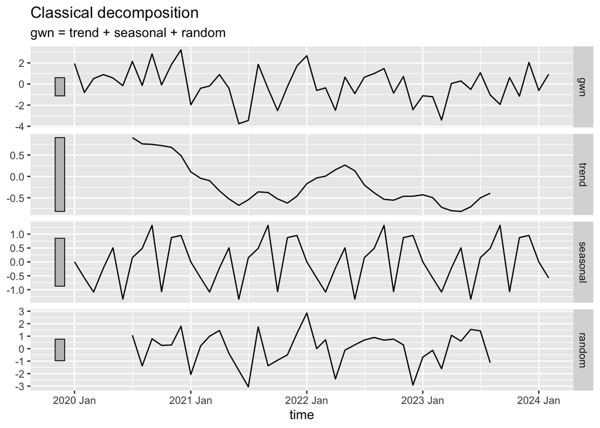

```r
autoplot(decomp)
```

#### d) Please evaluate the estimates of the trend and seasonal component.

**NoteAnswer**

#### a) Simulate a realization of a white noise process using the Exponential distribution. If $s_t$ is the realization from an exponentially distributed random variable, use the white noise $w_t=s_t-\lambda$ for your simulation. The length of the series is 500 points and $\lambda=1$. Please plot your simulation.

**NoteAnswer**

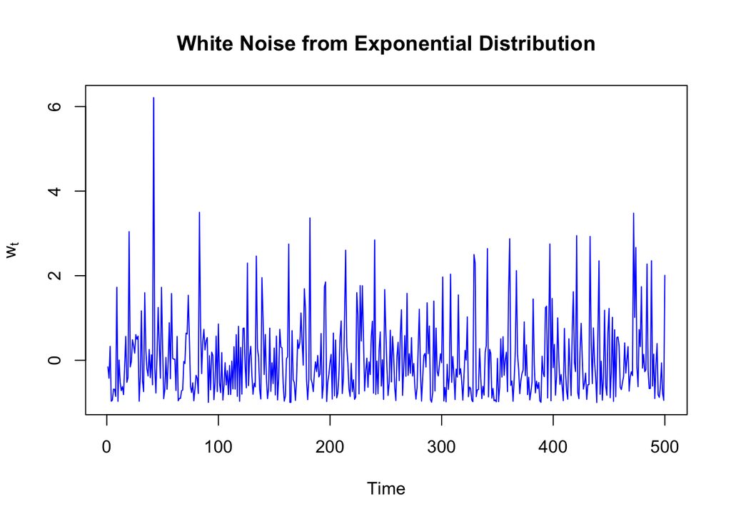

```r
# Parameters
n <- 500
lambda <- 1

# Simulate exponentially distrubuted random variable
set.seed(123)
s_t <- rexp(n, rate = lambda)

# Create while noise
w_t <- s_t - lambda

plot(w_t, type = "l",
     main = "White Noise from Exponential Distribution",
     xlab = "Time",
     ylab = expression(w[t]),
     col = "blue")
```

[output not shown]

**NoteAnswer**

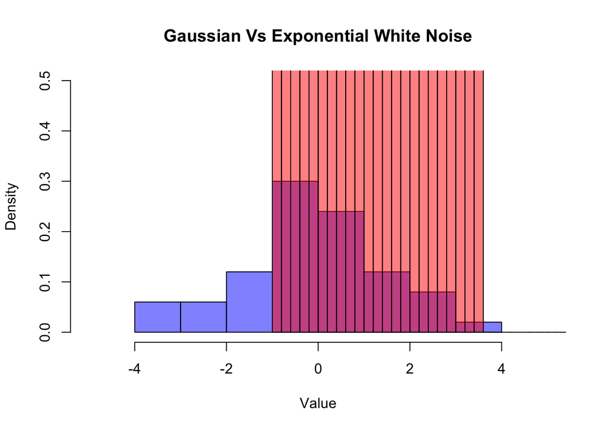

```r
hist(gwn,
     col = rgb(0,0,1,0.5),
     probability = TRUE,
     xlim = c(-5,5),
     ylim = c(0,0.5),
     main = "Gaussian Vs Exponential White Noise",
     xlab = "Value",
     ylab = "Density")

hist(w_t,
     breaks = 30,
     col = rgb(1,0,0,0.5),
     probabilty = TRUE,
     add = TRUE)
```

#### c) Create a random walk series using the Exponential DWN simulations. Please plot the series.

**NoteAnswer**

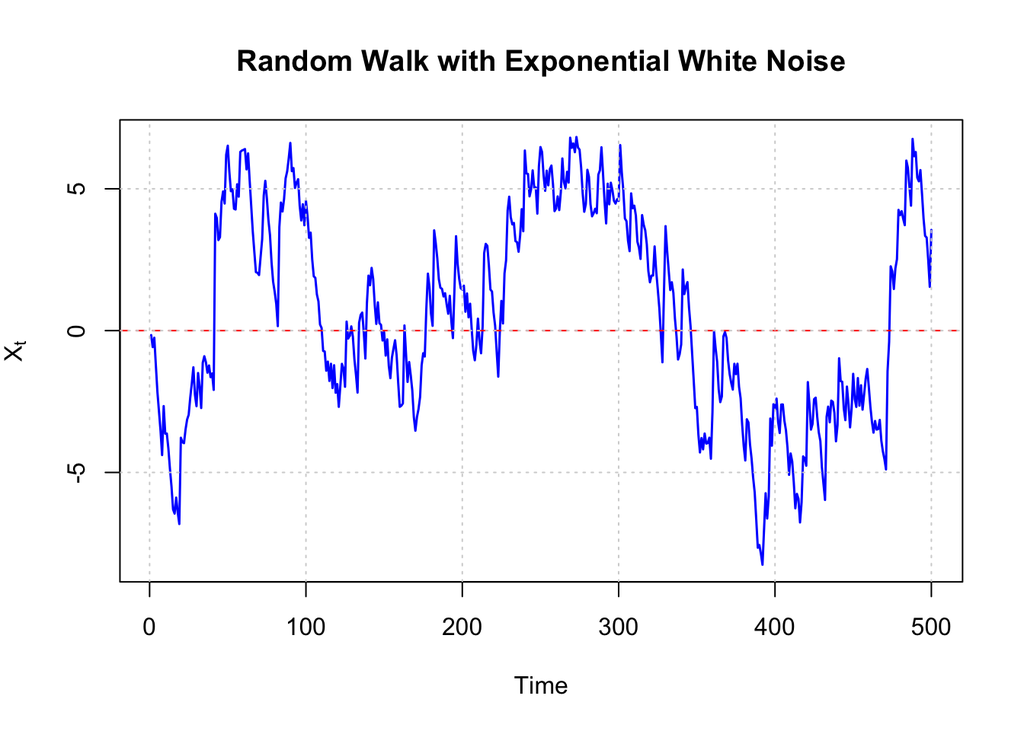

```r
# Set parameters
n <- 500
lambda <- 1

# Simulate Exponential White Noise
set.seed(123)
s_t <- rexp(n, rate = lambda)
exp_wn <- s_t - lambda

# Create Random Walk: X_t = X_{t-1} + w_t
# Starting value X_0 = 0
random_walk <- cumsum(exp_wn)

# Plot the random walk
plot(random_walk, type = "l",
     main = "Random Walk with Exponential White Noise",
     xlab = "Time",
     ylab = expression(X[t]),
     col = "blue",
     lwd = 1.5)
abline(h = 0, col = "red", lty = 2)
grid()
```

#### d) Use the Holt-Winters decomposition method to estimate the trend, seasonal, and random components of the series.

**NoteAnswer**

```r
# Generate the data
set.seed(123)
n <- 500
lambda <- 1
s_t <- rexp(n, rate = lambda)
exp_wn <- s_t - lambda
random_walk <- cumsum(exp_wn)

# Create a tsibble (not ts) for fable
ts_data <- tsibble(
  time = yearmonth(seq(as.Date("2020-01-01"), by = "month", length.out = n)),
  random_walk = random_walk,
  index = time
)

# Fit Holt-Winters model
hw_data <- ts_data %>%
  model(Additive = ETS(random_walk ~ error("A") + trend("A", alpha = 0.2, beta = 0.1) + season("A", gamma = 0.1)))

# View the model
report(hw_data)
```

```
Series: random_walk
Model: ETS(A,A,A)
  Smoothing parameters:
    alpha = 0.2
    beta  = 0.1
    gamma = 0.1

  Initial states:
      l[0]       b[0]      s[0]     s[-1]      s[-2]      s[-3]      s[-4]
 0.4311998 -0.3728711 0.2810971 0.3322754 0.01430199 -0.3064664 -0.2895473
      s[-5]      s[-6]     s[-7]      s[-8]     s[-9]    s[-10]    s[-11]
 -0.3890697 -0.2139308 -0.344081 0.04218326 0.2692437 0.3872202 0.2167735

  sigma^2:  2.9416

     AIC     AICc      BIC
3658.515 3659.381 3717.520
```

#### e) Please evaluate the estimates for the parameters of the model using the default algorithm settings (minimize the SS1PE).

**NoteAnswer**

```r
# Fit Holt-Winters model
hw_data_SS1PE <- ts_data %>%
  model(Additive = ETS(random_walk ~ error("A") + trend("A") + season("A")))

# View the model
report(hw_data_SS1PE)
```

```
Series: random_walk
Model: ETS(A,A,A)
  Smoothing parameters:
    alpha = 0.9559527
    beta  = 0.03690081
    gamma = 0.0001000132

  Initial states:
      l[0]       b[0]        s[0]       s[-1]      s[-2]      s[-3]      s[-4]
 -1.649174 -0.4634394 -0.06558742 0.007911802 -0.1396553 -0.3422996 -0.4201264
      s[-5]    s[-6]     s[-7]      s[-8]      s[-9]   s[-10]    s[-11]
 -0.2138025 0.271768 0.2153717 0.07413307 0.09058841 0.245117 0.2765813

  sigma^2:  0.9652

     AIC     AICc      BIC
3107.357 3108.627 3179.006
```

### Rubric

[output not shown]